# Data Viz 1: Charts and Graphs

## Learning Objectives

By the end of this practical lab you will be able to:

- Make basic plots in R
- Implement common graph types using the functions of the ggplot2 package

## Basic Plotting in Base R

First we will read in some 2011 census data for the UK that we will used for the practical.

```r
census <- read.csv("./data/census_small.csv")
```

This should look as follows…

```r
head(census)
```

```
##        Code                     Ward PCT_Good_Health PCT_Higher_Managerial
## 1 E05000886 Allerton and Hunts Cross        48.97327             10.091491
## 2 E05000887                  Anfield        42.20538              2.912621
## 3 E05000888               Belle Vale        40.84911              3.931920
## 4 E05000889                  Central        58.62832              7.019923
## 5 E05000890                Childwall        51.90538             10.787704
## 6 E05000891                   Church        53.39201             17.437790
##   PCT_Social_Rented_Households
## 1                    13.005190
## 2                    22.772576
## 3                    42.555119
## 4                    18.363917
## 5                     6.937488
## 6                     3.025153
```

Not much inthis data but it is enough to get a feeling how the data can look like. Code corresponds to the name of a ward, a ward is a small spatial administrative unit. The three variables are percentage of people who said on the census day that they think they are of good health, the second variable represents percentage of people with higher managerial salaries and the third one corresponds to the percentage of socially rented housing.

As we showed in an earlier practical (Descriptive Statistics), we can provide a summary of the attributes using the summary() function:

```r
summary(census)
```

```
##      Code               Ward           PCT_Good_Health PCT_Higher_Managerial
##  Length:30          Length:30          Min.   :37.32   Min.   : 2.418
##  Class :character   Class :character   1st Qu.:43.47   1st Qu.: 3.701
##  Mode  :character   Mode  :character   Median :46.36   Median : 5.215
##                                        Mean   :46.68   Mean   : 7.012
##                                        3rd Qu.:48.96   3rd Qu.: 9.962
##                                        Max.   :58.63   Max.   :17.438
##  PCT_Social_Rented_Households
##  Min.   : 3.025
##  1st Qu.:15.372
##  Median :21.930
##  Mean   :26.629
##  3rd Qu.:34.563
##  Max.   :57.993
```

However, it is also useful to graphically present the distributions. We can create a histogram using the hist() function, with additional options to specify the labels and color (these use [hex values](http://www.color-hex.com/)).

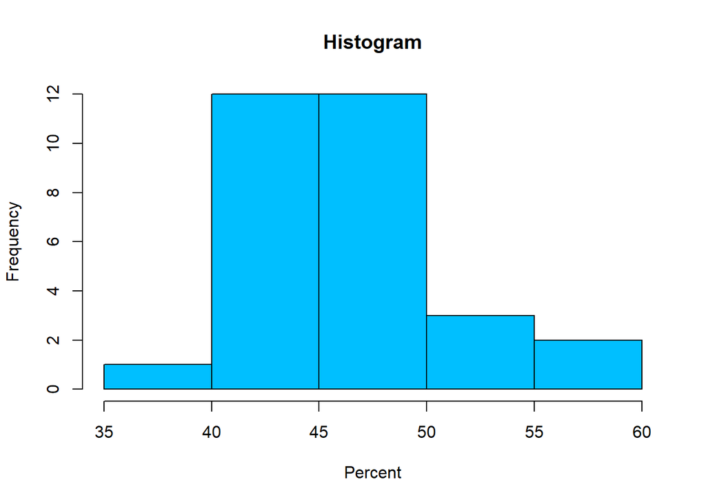

```r
#Historgram
hist(census$PCT_Good_Health, col="#00bfff", xlab="Percent", main="Histogram")
```

We might also be interested in the relationship between two variables. In the following plot, we show how the proportion of people who identify themselves as in good health within an area relate to the proportion of people who are living within socially rented housing.

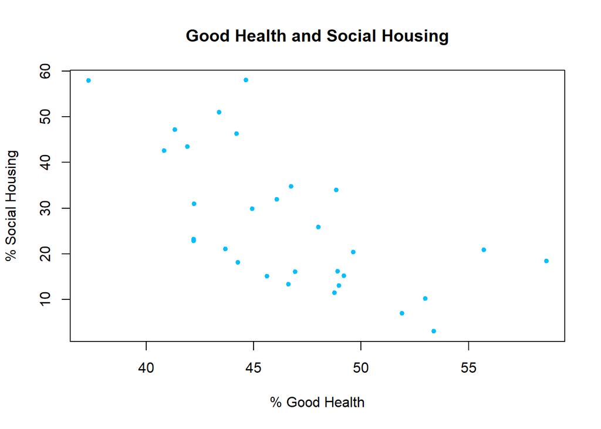

```r
plot(census$PCT_Good_Health,census$PCT_Social_Rented_Households,cex=.7,main="Good Health and Social Housing", xlab="% Good Health",ylab="% Social Housing",col="#00bfff",pch=19)
```

As was shown in a previous practical (Descriptive statistics), a mean can be calculated as follows:

```r
mean(census$PCT_Good_Health)
```

```
## [1] 46.67722
```

We can then use this to test each of numbers contained in the “PCT_Good_Health” column.

```r
census$PCT_Good_Health < mean(census$PCT_Good_Health)
```

```
##  [1] FALSE  TRUE  TRUE FALSE FALSE FALSE  TRUE  TRUE FALSE FALSE  TRUE FALSE
## [13] FALSE  TRUE  TRUE  TRUE FALSE  TRUE  TRUE FALSE  TRUE FALSE FALSE  TRUE
## [25]  TRUE  TRUE FALSE FALSE  TRUE  TRUE
```

Which returns some TRUE and some FALSE values. We can then combine this with an ifelse() function to create a new variable called “target”. The ifelse() returns (rather than TRUE and FALSE) a value specified by the latter two parameters of the function. In this case, these are the strings “Yes” and “No”.

```r
# Calculate a target for PCT in good health
census$target <- ifelse(census$PCT_Good_Health < mean(census$PCT_Good_Health),"Yes","No")
# Calculate a target for PCT social housing
census$target2 <- ifelse(census$PCT_Social_Rented_Households < mean(census$PCT_Social_Rented_Households),"Yes","No")
```

You will now see that these values have been added as a new variable in the data frame object:

```r
head(census)
```

```
##        Code                     Ward PCT_Good_Health PCT_Higher_Managerial
## 1 E05000886 Allerton and Hunts Cross        48.97327             10.091491
## 2 E05000887                  Anfield        42.20538              2.912621
## 3 E05000888               Belle Vale        40.84911              3.931920
## 4 E05000889                  Central        58.62832              7.019923
## 5 E05000890                Childwall        51.90538             10.787704
## 6 E05000891                   Church        53.39201             17.437790
##   PCT_Social_Rented_Households target target2
## 1                    13.005190     No     Yes
## 2                    22.772576    Yes     Yes
## 3                    42.555119    Yes      No
## 4                    18.363917     No     Yes
## 5                     6.937488     No     Yes
## 6                     3.025153     No     Yes
```

A basic bar chart showing the frequency of zones within each category can be generated as follows:

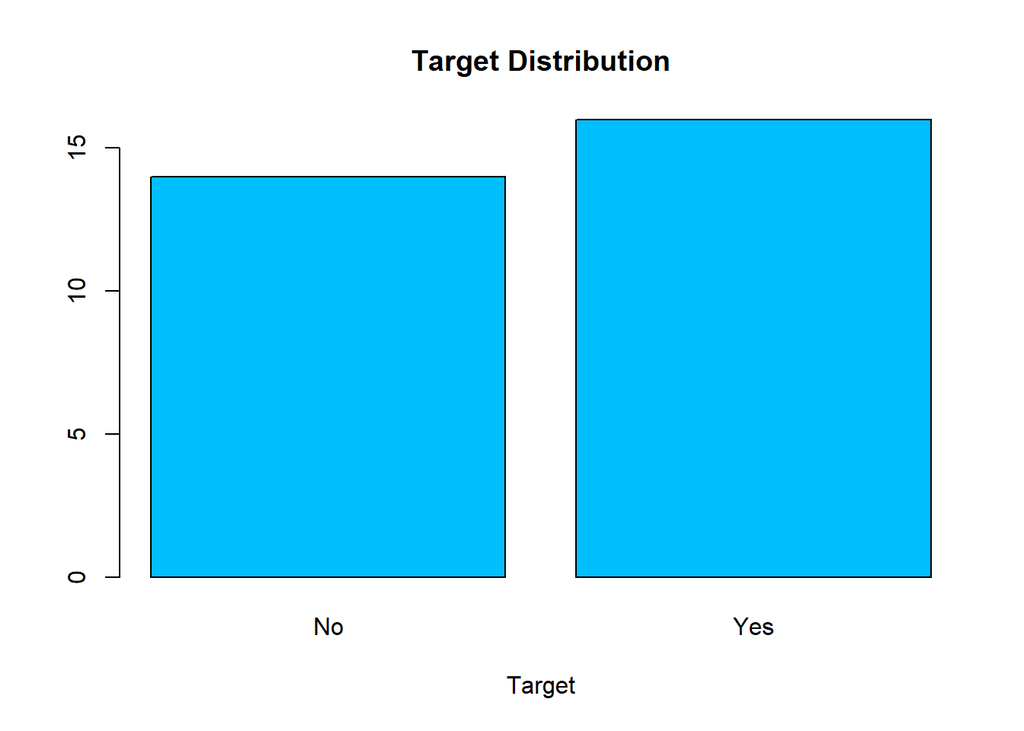

```r
#Create a table of the results
counts <- table(census$target)

barplot(counts, main="Target Distribution", xlab="Target",col="#00bfff")
```

You can also created stacked and side by side bar charts:

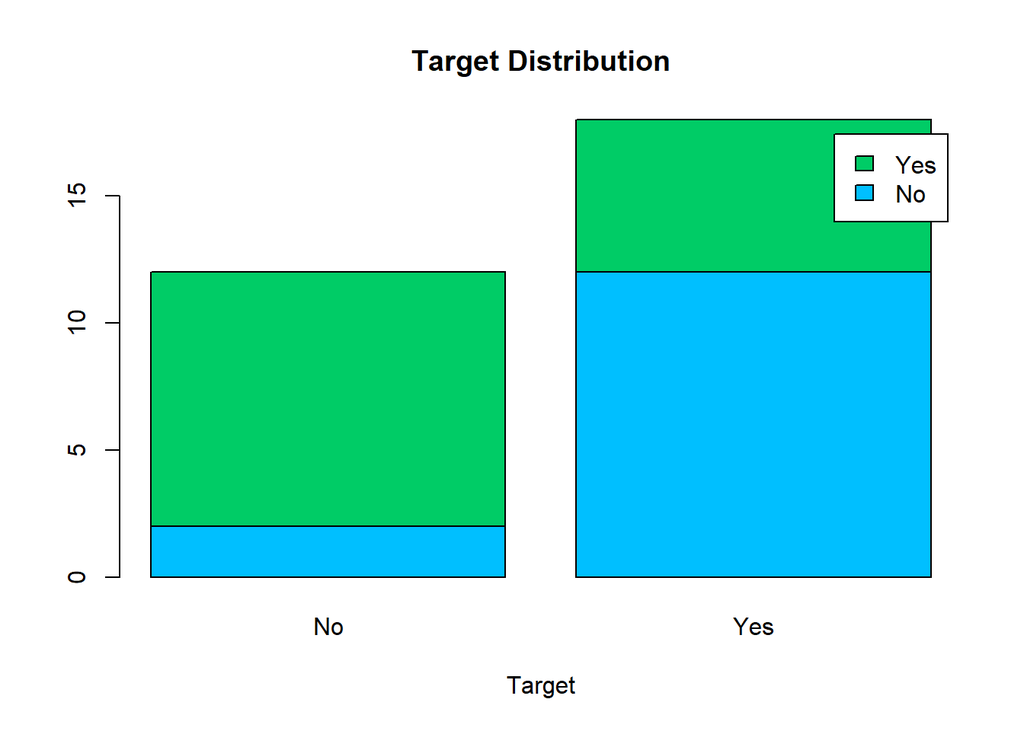

```r
#Create a table of the results
counts <- table(census$target, census$target2)

#Create stacked bar chart
barplot(counts, main="Target Distribution", xlab="Target",col=c("#00bfff","#00cc66"),legend = rownames(counts))
```

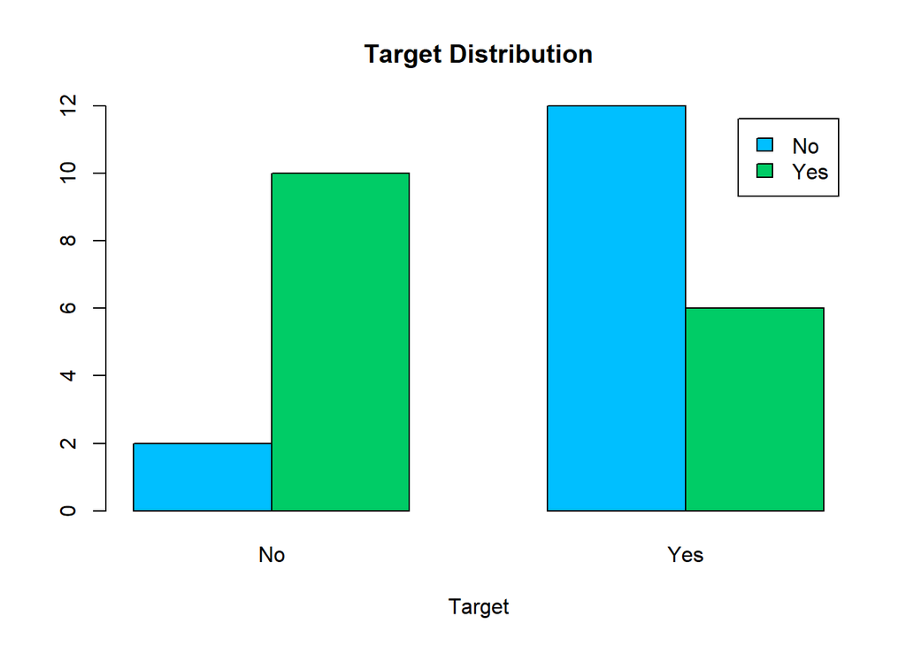

```r
#Create side by side bar chart
barplot(counts, main="Target Distribution", xlab="Target",col=c("#00bfff","#00cc66"),legend = rownames(counts),beside=TRUE)
```

We will now read in another dataset that shows the population of different racial groups within [New York City between 1970 and 2010](https://en.wikipedia.org/wiki/Demographic_history_of_New_York_City).

```r
#Read data
racial <- read.csv("./data/NYC_Pop.csv")
```

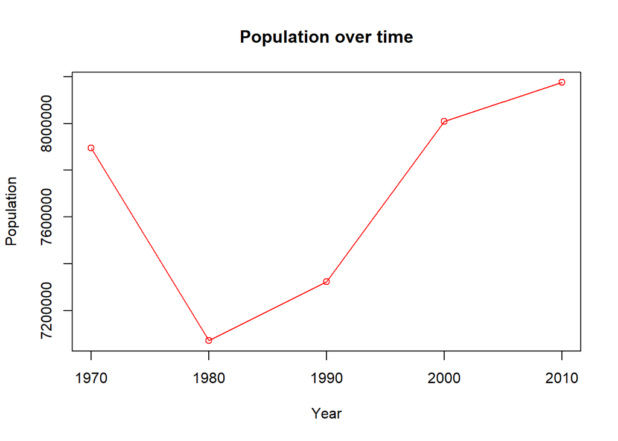

```r
#Create a plot for the total population without an x-axis label
plot(racial$Population,type = "o", col = "red", xlab = "Year", ylab = "Population", main = "Population over time",xaxt = "n")
# Add axis label
axis(1, at=1:5, labels=racial$Year)
```

It is also possible to add multiple lines to the plot using the lines() function:

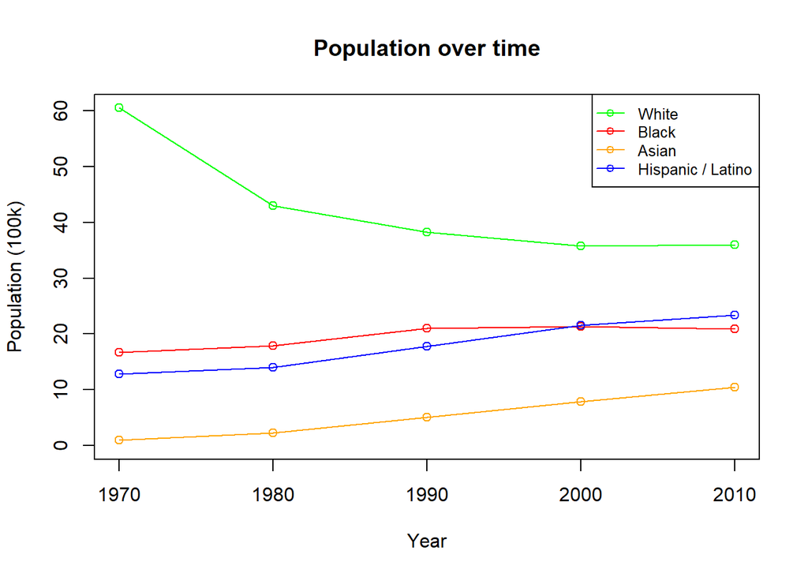

```r
#Create a plot for the total population without an x-axis label
plot((racial$White)/100000,type = "o", col = "green", xlab = "Year", ylab = "Population (100k)", main = "Population over time",xaxt = "n",ylim=c(0,max(racial$White/100000)))

lines(racial$Black/100000, type = "o", col = "red")
lines(racial$Asian/100000, type = "o", col = "orange")
lines(racial$Hispanic_Latino/100000, type = "o", col = "blue")

# Add axis label
axis(1, at=1:5, labels=racial$Year)

#Add a legend
legend("topright", c("White","Black","Asian","Hispanic / Latino"), cex=0.8, col=c("green","red","orange","blue"),pch=1, lty=1)
```

## Some additiaonl graphs with built in dataset: Cars

Around 100 datasets are supplied with R (in package datasets), and others are available in packages (including the recommended packages supplied with R). To see the list of datasets currently available, use:

```r
data()
```

All the datasets supplied with R are available directly by name. However, many packages still use the obsolete convention in which data was also used to load datasets into R, for example:

```r
data(cars)   # a data frame with 50 observations, containing the speed and stopping distances of cars.
cars         # you can have a look at the data.
data(mtcars) # a data frame with 32 observations, containing fuel consumption and 10 aspects of automobile design and performance for 32 automobiles.
mtcars
```

One of the most frequently used plotting functions in R is the plot() function. This is a generic function: the type of plot produced is dependent on the type or class of the first argument.

You should always place the independent variable on the x-axis (horizontal axis). X is entered first in the plot() function

The dependent variable (outcome) is always placed on the y-axis (vertical axis). Y is entered second in the plot() function

## plotting x

If x is a time series, this produces a time-series plot. If x is a numeric vector, it produces a plot of the values in the vector against their index in the vector.

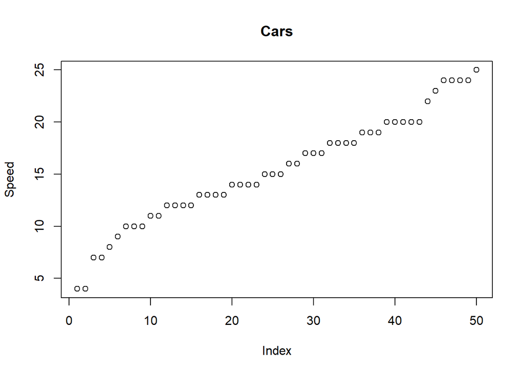

```r
plot(x=cars[,1], main="Cars", xlab="Index", ylab="Speed")
```

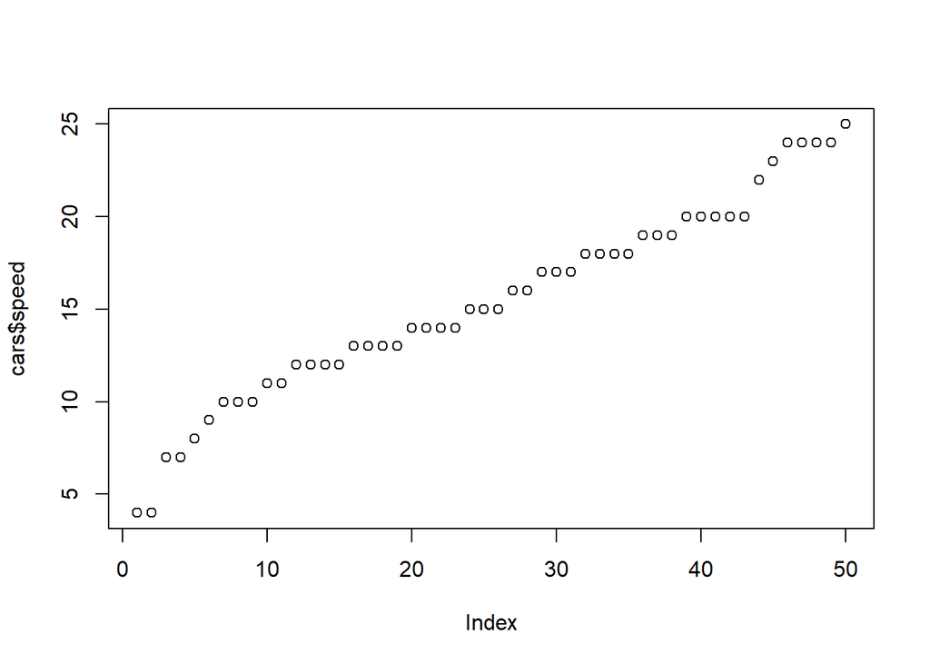

```r
plot(cars$speed)
```

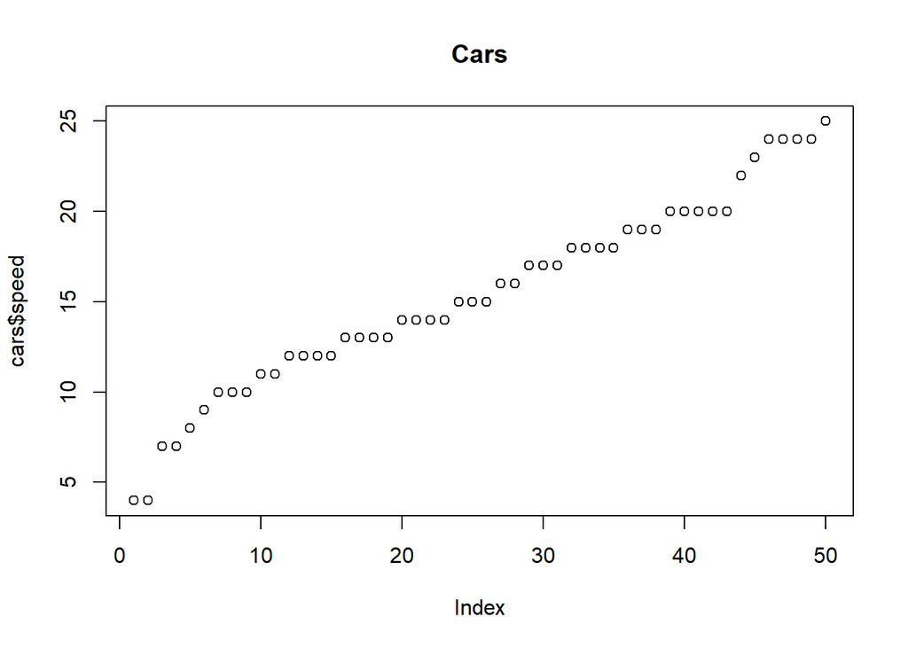

```r
plot(cars$speed, main="Cars")
```

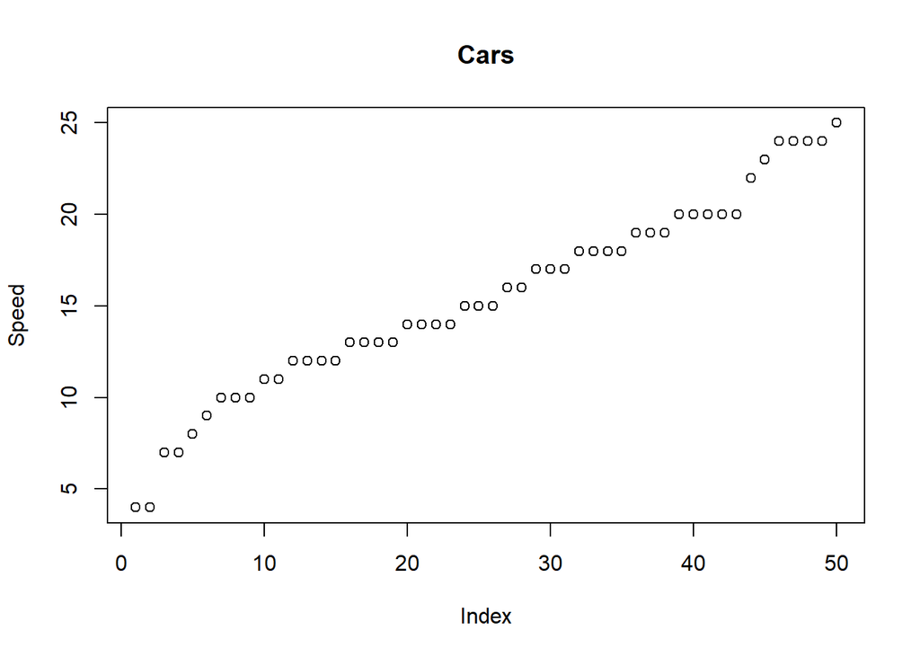

```r
plot(cars$speed, main="Cars", xlab="Index", ylab="Speed")
```

## plotting x,y

If x and y are vectors, plot(x, y) produces a scatterplot of y against x. The same effect can be produced by supplying one argument (second form) as either a list containing two elements x and y or a two-column matrix.

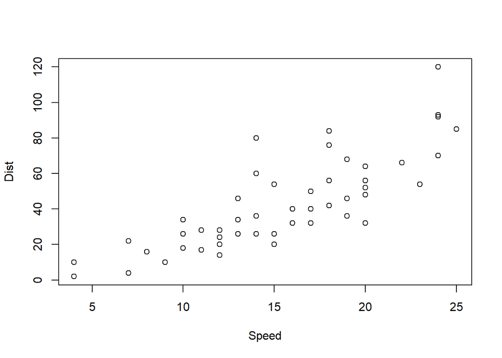

```r
# the following two commands generate the same graphs
plot(x=cars[,1], y=cars[,2], xlab="Speed", ylab="Dist")
```

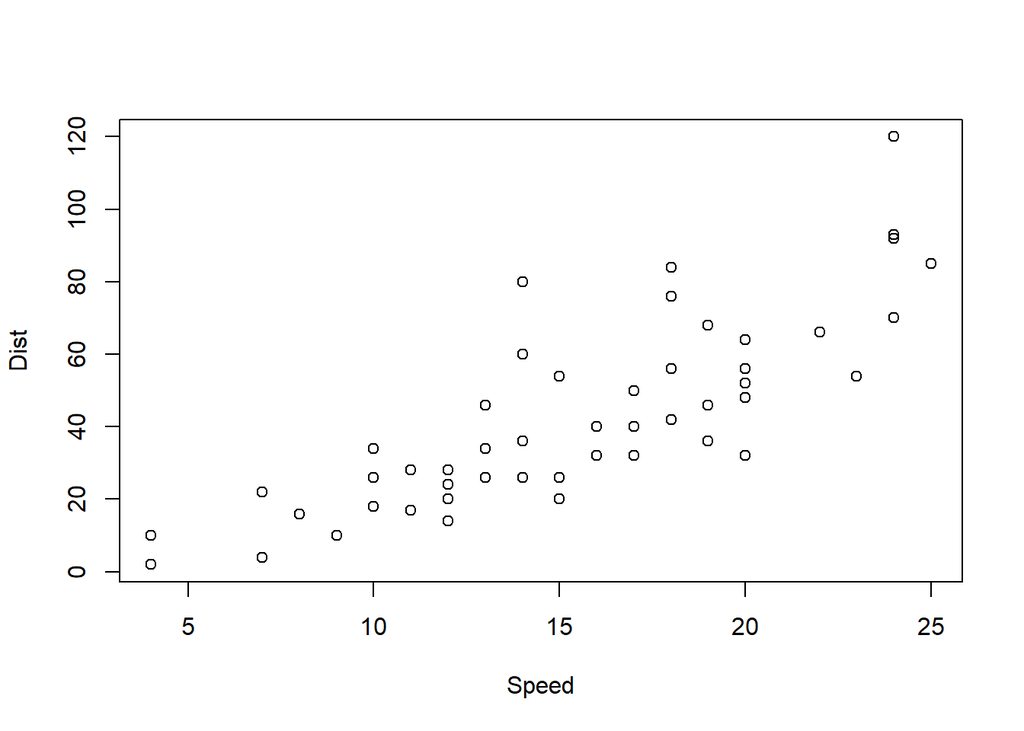

```r
plot(cars, xlab="Speed", ylab="Dist")
```

## Add elements to your plot

You can add extra information (such as points, lines or text) to the current plot using following functions: points(x, y) lines(x, y) text(x, y, labels, .) abline(a, b) polygon(x, y, …) legend(x, y, legend, …) title(main, sub) axis(side, .)

```r
# discrete distribution
# type "h": ‘histogram’ like (or ‘high-density’) vertical lines.
# other types: "p" (points), "l" (lines),"b" (both), "n" (no plotting) and so on.
```

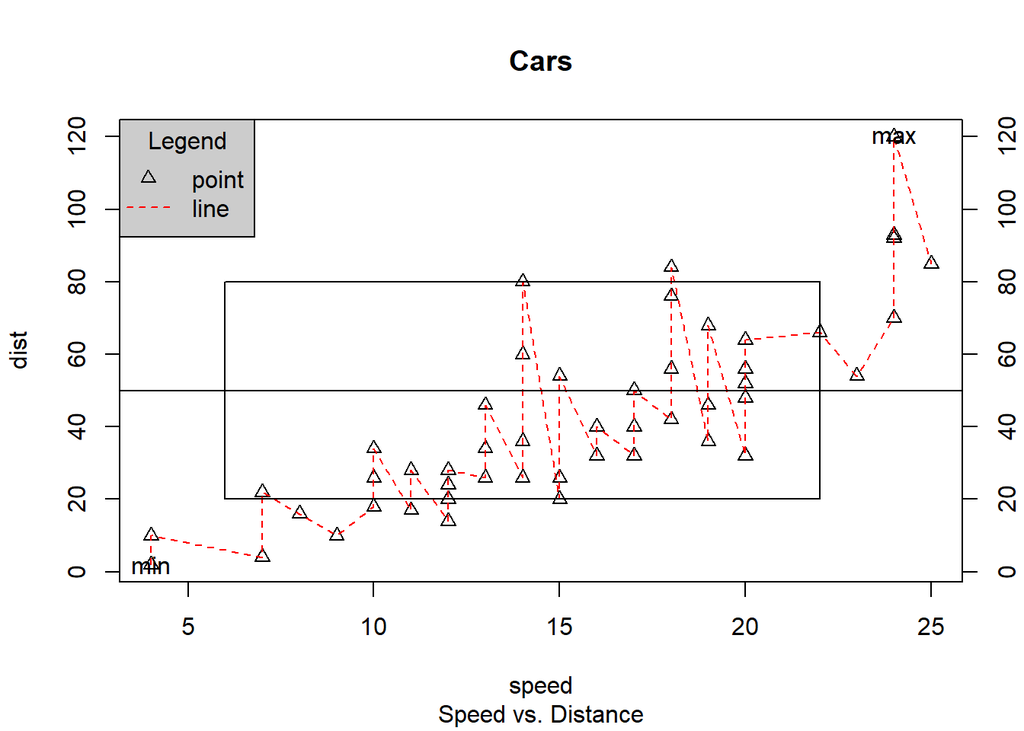

```r
# generate a blank graph with axis
plot(cars, type = "n")

# Adds points to the current plot
points(cars$speed, cars$dist, pch = 2)

# Adds connected lines to the current plot
lines(cars$speed, cars$dist, col = "red", lty = 2)

# Add text to a plot
text(c(4,24), c(2,120), c("min","max"))


# Adds a horizontal line
abline(h=50)


# Draws a polygon defined by the ordered vertices
polygon(c(6,6,22,22), c(20,80,80,20))


# Adds a legend to the current plot at the specified position
legend(x="topleft",legend=c("point","line"), col = c("black","red"),
       lty = c(NA, 2), pch = c(2, NA), title = "Legend", bg = "gray80")

# Adds a title main to the top of the current plot in a large font and a sub-title sub at the bottom in a smaller font.
title("Cars","Speed vs. Distance")

# Adds an axis to the current plot on the side given by the first       argument (1 to 4, counting clockwise from the bottom.)
axis(side=4)
```

## Basic Graphing with ggplot2

The ggplot2 library provides a range of functions that make graphing and visualization of your data both visually appealing and simple to implement. There are two ways in which graphs can be created in ggplot2, the first is ggplot() which we will discuss later, and the second is qlot(), which has a simplified syntax.

```r
library(ggplot2)
```

### Bar Charts

We can first create a bar chart using the factor column (“target”) of the data frame object “census”. The “geom” attribute is telling `qplot` what sort of plot to make. If you remember from the last practical, the target variable were wards within Liverpool where the percentage of people in good health was less than the city mean.

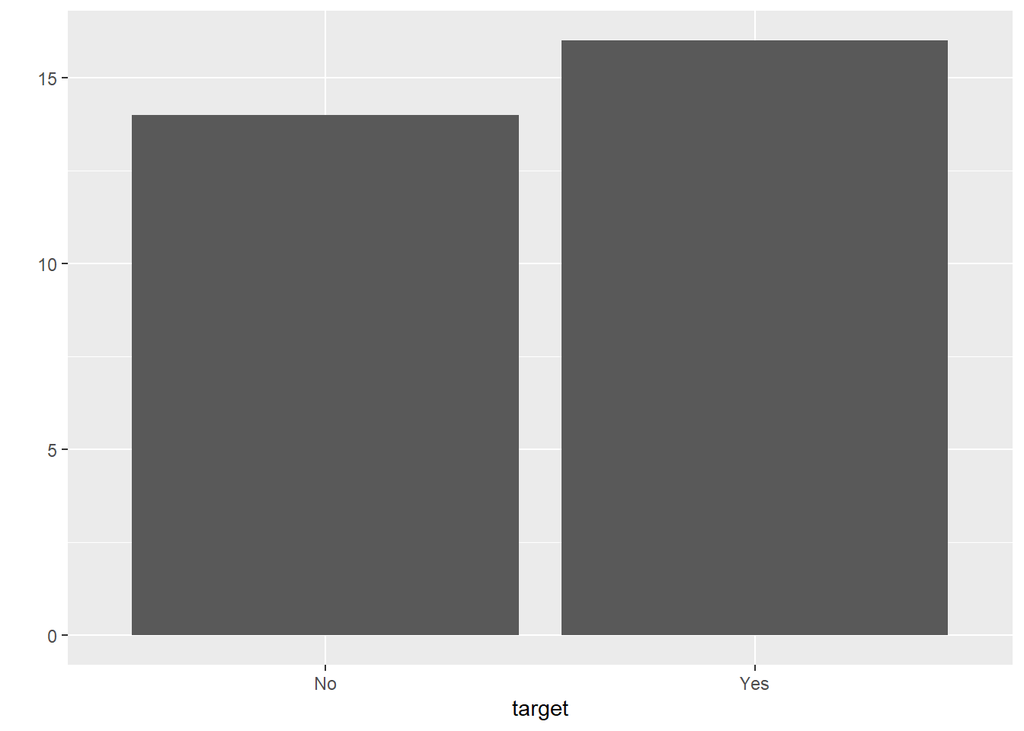

```r
qplot(target,  data=census, geom="bar")
```

### Histogram

We can create a histogram by changing the “geom” and variable being plotted. Try adjusting the bin width, which alters the bins into which the values of the “PCT_Social_Rented_Households” column are aggregated.

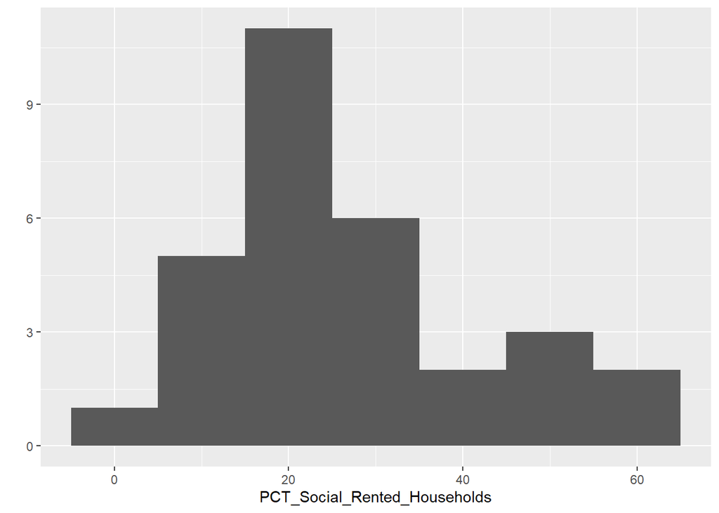

```r
qplot(PCT_Social_Rented_Households, data=census, geom="histogram",binwidth=10)
```

### Scatterplot

Another very common type of graph is a scatterplot which will typically plot the values of two continuous variables against one another on the x and y axis of the graph. This graph looks at the relationship between the percentage of people in socially rented housing, and those who are occupied in higher managerial roles. The default plot type is a scatterplot, so note in the next couple of examples we do not include `geom = "point"`, however, this could be added and would return the same result (try it!)

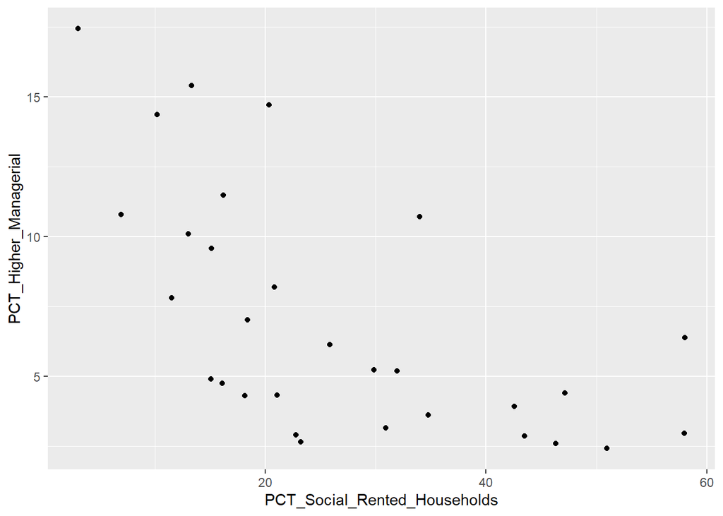

```r
qplot(PCT_Social_Rented_Households, PCT_Higher_Managerial, data = census)
```

### Adding colours or shapes

In the previous graph, all the points were black, however, if we swap these out for color, we can highlight a factor variable, which in this case is the “target” column.

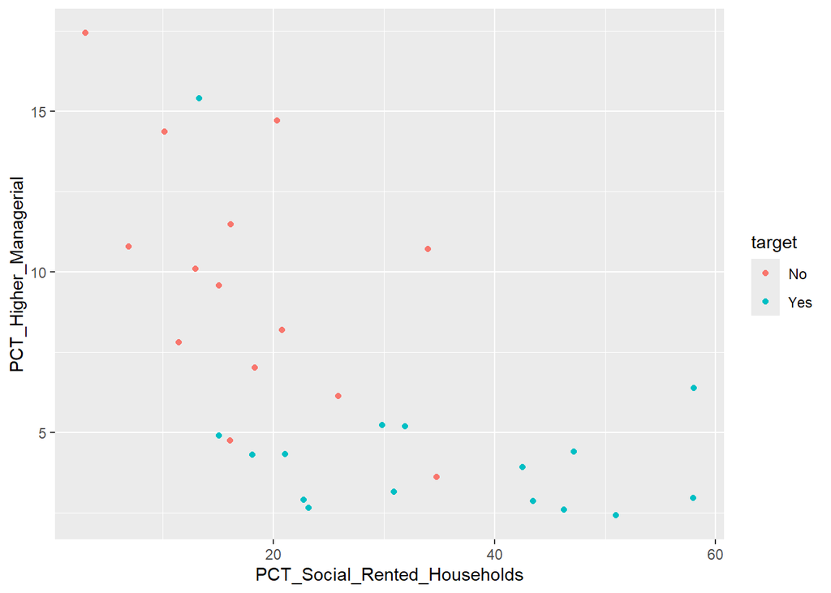

```r
qplot(PCT_Social_Rented_Households, PCT_Higher_Managerial, data = census,colour=target)
```

Alternatively, you can also use “shape” to keep the points as black, but alter their shape by the factor variable.

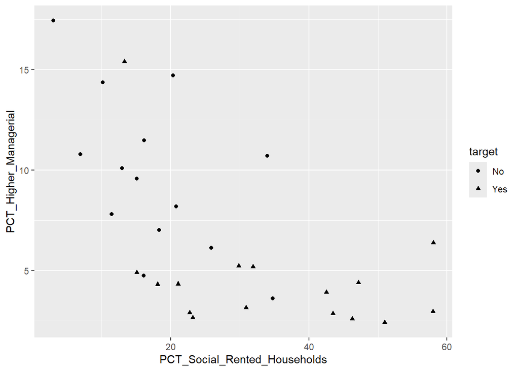

```r
qplot(PCT_Social_Rented_Households, PCT_Higher_Managerial, data = census,shape=target)
```

### Adding a smoothed line

If we want to add a trend line to the plot this is also possible by adding an addition parameter to the “geom”.

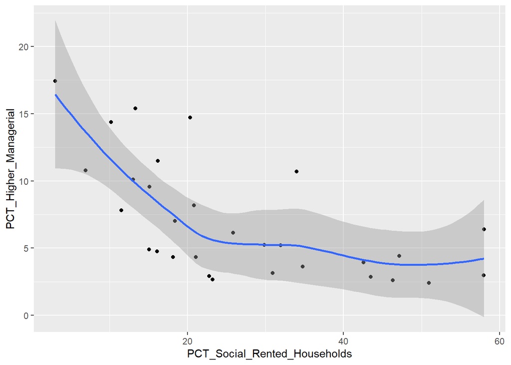

```r
qplot(PCT_Social_Rented_Households, PCT_Higher_Managerial, data = census,geom = c("point","smooth"))
```

We might also want a simpler linear regression line; which requires two further parameters including “method”” and “formula”.

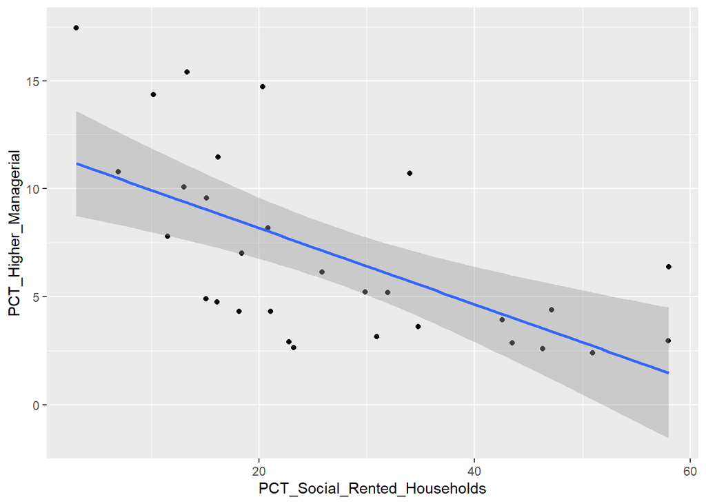

```r
qplot(PCT_Social_Rented_Households, PCT_Higher_Managerial, data = census,geom = c("point","smooth"),method="lm", formula=y~x)
```

### Line Plots

To illustrate how to create line plots we will read in some economic data downloaded from the [Office for National Statistics](http://www.ons.gov.uk/ons/site-information/using-the-website/time-series/index.html#2) which concerns household expenditure since 1948.

```r
household_ex <- read.csv("./data/expenditure.csv")
```

We can then have a quick look at the data and check on the data class.

```r
head(household_ex)
```

```
##   Year Millions
## 1 1948   191274
## 2 1949   194639
## 3 1950   200097
## 4 1951   197686
## 5 1952   197993
## 6 1953   206868
```

```r
str(household_ex)
```

```
## 'data.frame':    67 obs. of  2 variables:
##  $ Year    : int  1948 1949 1950 1951 1952 1953 1954 1955 1956 1957 ...
##  $ Millions: int  191274 194639 200097 197686 197993 206868 215626 224699 226305 231475 ...
```

We can now attempt to plot the data.

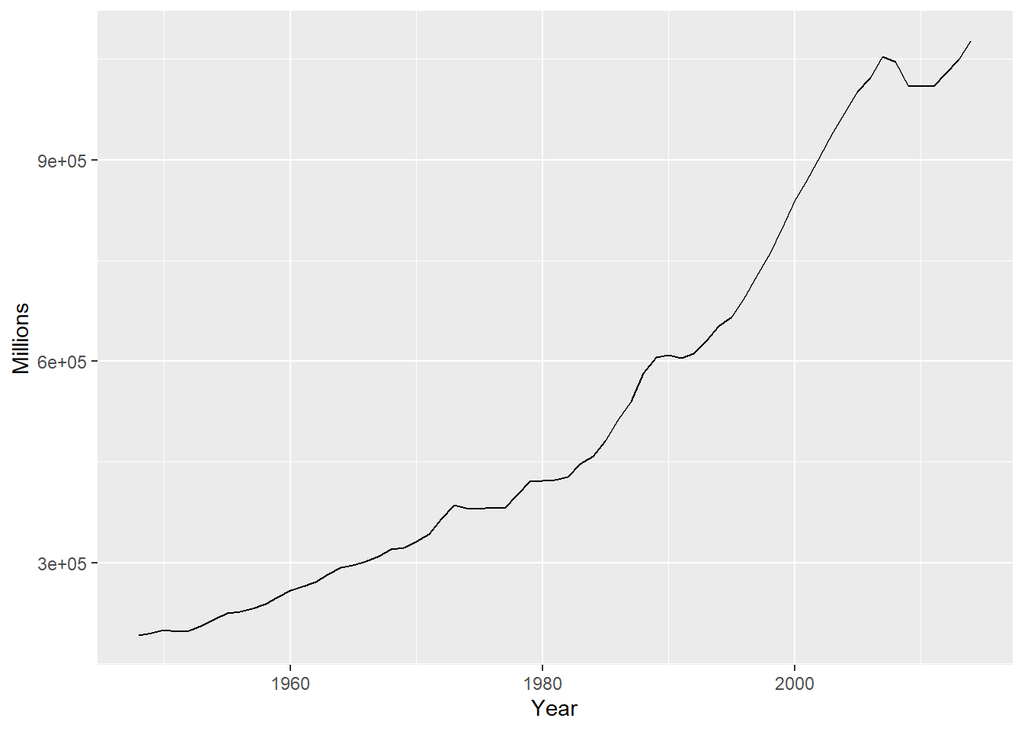

```r
qplot(Year, Millions, data = household_ex, geom = "line")
```

### Changing axis and labels

On the y axis, ggplot2 has defaulted to using scientific notation. We can change this, however, we will swap to the main ggplot syntax in order to do this. The first stage is to setup the plot, telling ggplot what data to use, and which “aesthetic mappings” (variables!) will be passed to the plotting function. In fact aes() is a function, however never used outside of ggplot(). This is stored in a variable “p”

```r
p <- ggplot(household_ex, aes(Year, Millions))
```

If you just typed “p” into the terminal this would return an error as you still need to tell ggplot() which type of graphical output is desired. We do this by adding additional parameters using the “+” symbol.

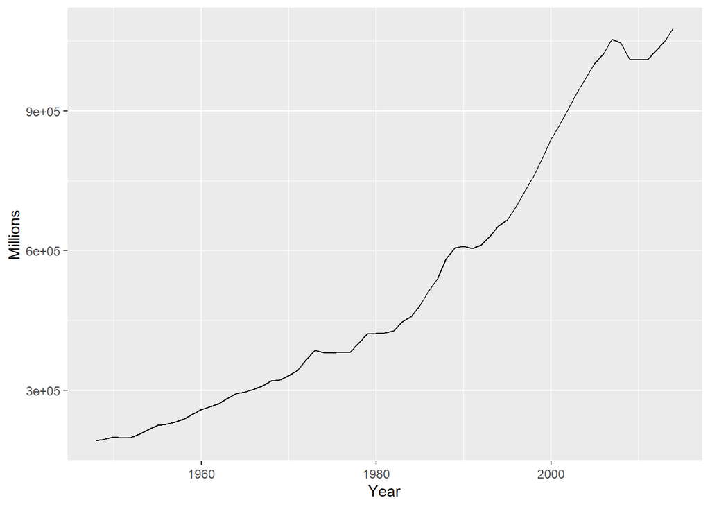

```r
p + geom_line()
```

Swapping out the scientific notation requires another package called “scales”. Once loaded, we can then add an additional parameter onto the graph.

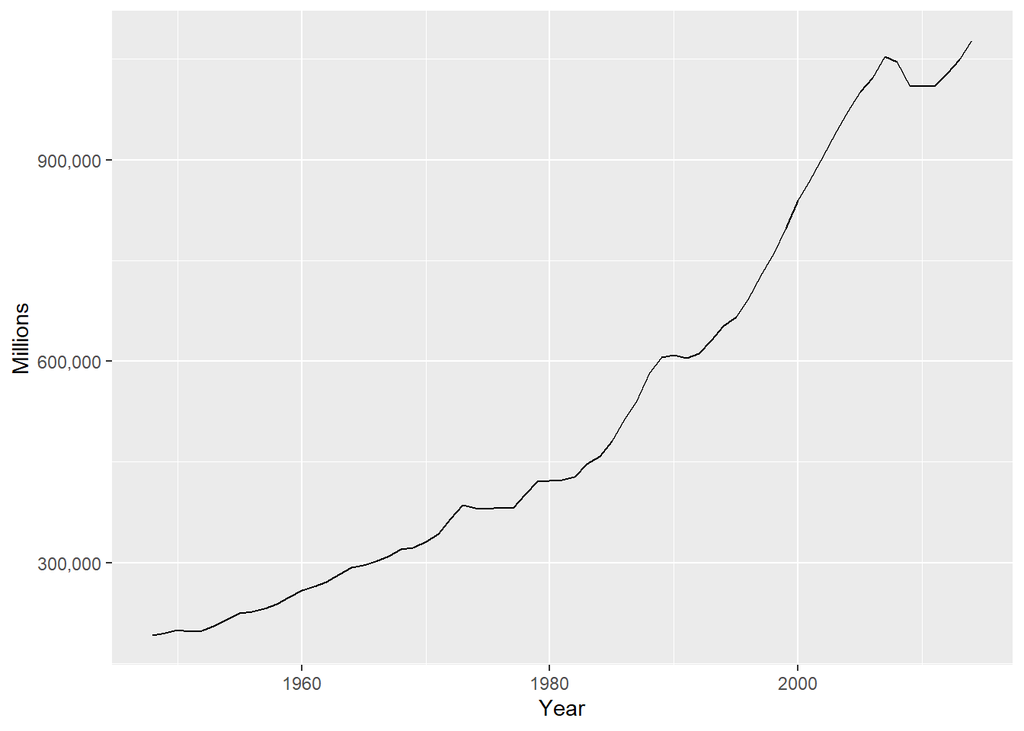

```r
library(scales)
p + geom_line() + scale_y_continuous(labels = comma)
```

We can also change the x and y axis labels

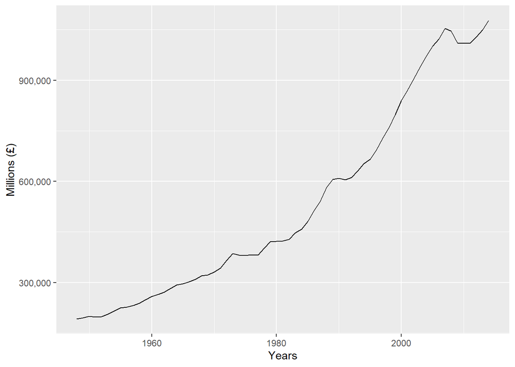

```r
# Add scale labels
p <- p + geom_line() + scale_y_continuous(labels = comma) + labs(x="Years", y="Millions (£)")
# Plot p
p
```

## try to figure out how to plot boxplots :)

https://r-graph-gallery.com/267-reorder-a-variable-in-ggplot2.html

# Further resources / training

- [ggplot2](http://docs.ggplot2.org/current/) - details and examples of many different types of plot
- [plot.ly R examples](https://plot.ly/r/) - lots of examples and code for using R and plot.ly together